# Question-Answering Demo using Scottish Widows Public Documents

## Introduction

To harness the power of LLMs and improve the pretrained models' performance, there are basically three routes one can try: Prompt Engineering, [Retrieval-Augmented Generation (RAG)](https://arxiv.org/abs/2005.11401) or model Finetuning.

The RAG approach integrates the power of retrieval (or searching) into LLM text generation. It combines a retriever system, which fetches relevant document snippets from domain specific data, and an LLM, which produces answers using the information from those snippets. In essence, RAG helps the model to “look up” external information to improve its responses.

Specifically, for the vector similarity search based RAG approach, all the relevant text data such as PDFs or other documentation are chunked first. Then all the chunks are embedded into vectors and store in a vector database. When a user asks a question, the question is also embedded and a search is conducted to find the similar chunks in the embedded sapce in the hope that the most relevant answers are clustered around the question in the embedding vector space. After this retrival stage, the relevant text are extracted and use to form the context to prompt the LLM to generate an answer.

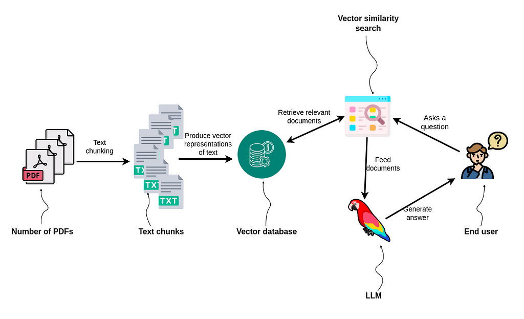

[image source](https://neo4j.com/developer-blog/knowledge-graphs-llms-multi-hop-question-answering/)

## Environment

```python
import os

import pandas as pd
import numpy as np

import faiss


pd.options.display.max_rows = 100
pd.options.display.max_columns = 100
```

```python
import vertexai
from vertexai.preview.language_models import TextGenerationModel, TextEmbeddingModel
```

```python
PROJECT_ID = ! gcloud config get core/project
PROJECT_ID = PROJECT_ID[0]

REGION = "europe-west1"

PROJECT_ID, REGION
```

```
('playpen-2a0efe', 'europe-west1')
```

```python
%env PROJECT_ID=$PROJECT_ID
```

```
env: PROJECT_ID=playpen-2a0efe
```

## Data

### Raw data

Document Source: Based on Scottish Widows' literature library search: https://adviser.scottishwidows.co.uk/literature-library.html

Specifically for this demo, the *guides* are selected: https://adviser.scottishwidows.co.uk/literature-library.html?n=1000&filter=swe:literaturelibrary/contenttype/guides

The pdf files are scrapped and save in local parquet file

```python
all_guides_file = "../data/scottish_widows_all_guides.pq"

guides_df = pd.read_parquet(all_guides_file)

guides_df.head()
```

|  | page_number | page_text | title |
| --- | --- | --- | --- |
| 0 | 1 | \n \n \nWhich trust form should I use? \n \n... | Which trust form should I use? |
| 1 | 2 | \n \n \n4. The Gift trust (creating fixed int... | Which trust form should I use? |
| 2 | 3 | \n \n \nPlease tick one of the boxes below to... | Which trust form should I use? |
| 3 | 1 | POLICY PROVISIONS\nBP-S32/S32A (2016)PLANBUYOU... | Trustee Buyout Plan Policy Provisions |
| 4 | 2 | PAGE 2\n1 PRELIMINARY\nPAGE 4\n2 UNIT-LINKED F... | Trustee Buyout Plan Policy Provisions |

```python
guides_df.groupby(["title"])[["page_number"]].count()
```

| title | page_number |
| --- | --- |
| A guide to pension tax | 11 |
| A guide to supporting vulnerability | 8 |
| Adviser guide to accessing income with Drip Feed Drawdown... | 19 |
| Advisers' Guide To The Portfolio Management Service | 36 |
| Annual FSA Insurance Returns for the year ended 31st Dece... | 189 |
| ... | ... |
| Scottish Widows Bank Premier Team Flyer | 2 |
| Scottish Widows Cash Fund weekly report | 2 |
| Scottish Widows Life Funds Investor's Guide | 54 |
| Scottish Widows OEIC and ISA brochure | 12 |
| Scottish Widows PIP withdrawal guide | 23 |

226 rows × 1 columns

### Pre-processing

#### Remove the blank pages

```python
print(guides_df.shape)

guides_df = guides_df.loc[guides_df["page_text"]!=""]

print(guides_df.shape)
```

```
(2976, 3)
(2952, 3)
```

## Embedding using Google's `TextEmbedding` Model

**Approach 1: Using the natural pages as chunks**

```python
guides_df["page_text"].loc[0]
```

```
" \n \n \nWhich trust form should I use?  \n \nFor life assurance (i.e. non pension) contracts which are already set up and on risk, Scottish Widows \ncurrently offers a choice of four trusts. To help you choose which trust is most appropriate for your \nneeds, a brief description of each trust and …
```

```python
model = TextEmbeddingModel.from_pretrained("textembedding-gecko@001")

# return a list of vertexai.language_models._language_models.TextEmbedding
#embeddings = model.get_embeddings( [guides_df["page_text"].loc[0]] )
embeddings = model.get_embeddings(guides_df["page_text"].loc[0:4]) # maximum 5 instance per embedding!

len(embeddings), type(embeddings[0])
```

```
(5, vertexai.language_models._language_models.TextEmbedding)
```

```python
for embedding in embeddings:
    vector = np.array(embedding.values)
    print(vector.shape)
    print(vector[:10])
```

```
(768,)
[ 0.01049513 -0.01476781 -0.00213589  0.01635158  0.01572042 -0.0659941
  0.03316933  0.03560591 -0.02210218  0.01482409]
(768,)
[-0.01333201 -0.01170563 -0.02743361  0.01251736  0.01605495 -0.05653438
  0.04348524  0.02655993 -0.0336807   0.01399777]
(768,)
[ 0.01591383 -0.01322624 -0.00728575 -0.00176922  0.02779969 -0.0607065
  0.00740999  0.02279622 -0.01332888  0.0173459 ]
(768,)
[-0.00177567 -0.0265304   0.01459018  0.00554964  0.00642882 -0.04269994
  0.00504656  0.03302064 -0.01718982  0.01577001]
(768,)
[-0.00341803 -0.02207155 -0.004032   -0.01826066 -0.01206415 -0.04291812
  0.01481962  0.01428669 -0.00667574  0.04736852]
```

```python
pd.Series([embedding.values for embedding in embeddings], name="embedding").to_frame()
```

|  | embedding |
| --- | --- |
| 0 | [0.010495134629309177, -0.014767814427614212, ... |
| 1 | [-0.013332009315490723, -0.011705626733601093,... |
| 2 | [0.0159138273447752, -0.013226243667304516, -0... |
| 3 | [-0.0017756749875843525, -0.026530398055911064... |
| 4 | [-0.0034180316142737865, -0.02207154966890812,... |

```python
def get_embedding_google(se, chunk_size=5):
    """Using Google's pretrained TextEmbeddingModel to vetorise the text series
       Input:
           se: Series of string
           chunk_size: number of text items send to Google API.
                       By default, GCP can process maximum 5 itmes in one go,
                       so the chunk_size should be less than 5
        Return: Numpy array with shape (m, n), where m is the number of text
                and n the vector length (768 for Google model)
    """

    model = TextEmbeddingModel.from_pretrained("textembedding-gecko@001")

    # generator use to iterate the series over smaller series with chunk_size rows)
    small_se_gen = (se.iloc[i:i+chunk_size] for i in range(0, len(se), chunk_size))
    small_se_embeddings = [model.get_embeddings(small_se) for small_se in small_se_gen]

    eb_list = [
        np.array(embedding.values, dtype="float32")
        for embeddings in small_se_embeddings
        for embedding in embeddings
        ]
    return np.vstack(eb_list)
```

**To test the embdding function**

```python
# one text item each time for the 11 items embedding
v1 = get_embedding_google(guides_df["page_text"].iloc[0:11], 1)
v1.shape, v1[0][0:10]
```

```
((11, 768),
 array([ 0.01048785, -0.01465903, -0.00213082,  0.01636567,  0.01568375,
        -0.06606973,  0.03323705,  0.03563511, -0.02214777,  0.01477051],
       dtype=float32))
```

```python
# using the default chunk size of 5
v2 = get_embedding_google(guides_df["page_text"].iloc[0:11])
v2.shape,  v2[0][0:10]
```

```
((11, 768),
 array([ 0.01049513, -0.01476781, -0.00213589,  0.01635158,  0.01572042,
        -0.0659941 ,  0.03316933,  0.03560591, -0.02210218,  0.01482409],
       dtype=float32))
```

**Note: when more than one piece of text items are send for embedding, the model returns slightly different embeddings vector. But they are very similar when using the dot product to compare!**

```python
[np.dot(v_1, v_2) for v_1, v_2 in zip(np.rollaxis(v1, 0), np.rollaxis(v2,0))]
```

```
[0.99999064,
 0.999993,
 0.9999926,
 0.999988,
 0.99999094,
 0.9999911,
 0.99999005,
 0.99999046,
 0.999987,
 0.9999883,
 0.9999908]
```

### Embedding the whole set

```python
#%%timeit -n 1 -r 1 # how long does is take? about 1 min for 1000 rows
#get_embedding_google(guides_df["page_text"].iloc[0:100])

guides_embedded_df = pd.DataFrame(
    get_embedding_google(guides_df["page_text"]), index=guides_df.index
)

guides_embedded_df.tail()
```

[output not shown]

```python
guides_df.shape, guides_embedded_df.shape
```

```
((2952, 3), (2952, 768))
```

```python
guides_embedded_file = "../data/scottish_widows_all_guides_embedded_v3.pq"
```

```python
# guides_embedded_df.to_parquet(guides_embedded_file)
```

## Vector DB using Faiss

```python
#guides_embedded_df = pd.read_parquet(guides_embedded_file)

guides_embedded_df.tail()
```

|  | 0 | 1 | 2 | 3 | 4 | 5 | 6 | 7 | 8 | 9 | 10 | 11 | 12 | 13 | 14 | 15 | 16 | 17 | 18 | 19 | 20 | 21 | 22 | 23 | 24 | 25 | 26 | 27 | 28 | … |
| --- | --- | --- | --- | --- | --- | --- | --- | --- | --- | --- | --- | --- | --- | --- | --- | --- | --- | --- | --- | --- | --- | --- | --- | --- | --- | --- | --- | --- | --- | --- |
| 2971 | 0.023005 | -0.008335 | 0.015968 | 0.020089 | -0.022411 | -0.082543 | -0.015963 | -0.020023 | -0.043214 | 0.014353 | -0.025780 | 0.001637 | 0.058558 | 0.008535 | 0.004042 | -0.049677 | -0.055249 | -0.017848 | 0.046654 | 0.017081 | -0.052548 | -0.004260 | 0.004665 | 0.028817 | 0.014689 | -0.077009 | 0.055519 | 0.019763 | -0.063145 | … |
| 2972 | 0.004236 | -0.039678 | 0.019605 | 0.014696 | 0.026340 | -0.076459 | 0.001416 | -0.021444 | -0.033944 | 0.008836 | -0.000315 | -0.001932 | 0.046890 | 0.052121 | -0.002347 | -0.020978 | -0.076301 | -0.017035 | 0.081462 | 0.033609 | -0.058328 | -0.026464 | 0.019679 | -0.001503 | 0.006444 | -0.073676 | 0.050129 | 0.000962 | -0.088607 | … |
| 2973 | 0.006069 | -0.048530 | 0.006824 | 0.000931 | 0.018895 | -0.069443 | -0.000718 | -0.028296 | -0.030608 | -0.000899 | -0.016570 | -0.030518 | 0.040158 | 0.046594 | 0.015070 | -0.039756 | -0.047341 | -0.026313 | 0.068929 | 0.053022 | -0.044780 | -0.020470 | 0.017019 | 0.004024 | 0.005173 | -0.086929 | 0.044768 | 0.005014 | -0.037550 | … |
| 2974 | 0.012338 | -0.027616 | 0.020484 | -0.012849 | -0.000070 | -0.065475 | 0.026028 | 0.016407 | 0.004235 | 0.012088 | -0.009587 | 0.012799 | 0.040866 | -0.013210 | -0.011045 | -0.016686 | -0.038683 | -0.019249 | 0.050640 | 0.024926 | -0.045360 | 0.016769 | -0.002324 | 0.023365 | -0.004998 | -0.053218 | 0.039008 | -0.010714 | -0.103057 | … |
| 2975 | 0.022185 | -0.033173 | 0.009347 | -0.024662 | 0.002580 | -0.057153 | 0.009860 | 0.017371 | -0.011084 | 0.018607 | -0.013448 | 0.017459 | -0.003734 | 0.014558 | -0.001503 | -0.031373 | -0.062036 | -0.010786 | 0.059708 | 0.001548 | -0.077247 | 0.012630 | -0.004428 | 0.015212 | 0.003572 | -0.075635 | 0.022557 | 0.024011 | -0.092295 | … |

5 rows × 768 columns

### Create unique ID to link embedded vectors with original page

```python
guides_df = guides_df.reset_index().rename(columns={"index": "id"})

guides_df.tail()
```

|  | id | page_number | page_text | title |
| --- | --- | --- | --- | --- |
| 2947 | 2971 | 21 | Guide to terminology\nEach individual investor... | Evaluating Scottish Widows Funds |
| 2948 | 2972 | 22 | Ratings\nMorningstar Rating™\nThe Morningstar ... | Evaluating Scottish Widows Funds |
| 2949 | 2973 | 23 | •\n•\n•Ratings\nFE fundinfo Crown Ratings\nFE ... | Evaluating Scottish Widows Funds |
| 2950 | 2974 | 24 | Risk Performance Analysis\nVolatility (absolut... | Evaluating Scottish Widows Funds |
| 2951 | 2975 | 25 | Risk Performance Analysis\nSharpe Ratio\nThe '... | Evaluating Scottish Widows Funds |

### Build the vector DB

```python
# instantiate the index
vector_length = guides_embedded_df.shape[1]

index = faiss.IndexFlatL2(vector_length)

# Pass the index to IndexIDMap and add vectors with IDs
indexed = faiss.IndexIDMap(index)
indexed.add_with_ids(guides_embedded_df, guides_df.id.values)

print(f"Number of vectors in the Faiss index: {indexed.ntotal}")
```

```
Number of vectors in the Faiss index: 2952
```

## Query

```python
# randomly pick up a page and search. The results should include itself as the closest match
pick_page = 15

em = guides_embedded_df.iloc[pick_page:pick_page+1, :]
distances, ids = indexed.search(em, k=3)
print(f'L2 distance: {distances[0]}\nIDs: {ids[0]}')
```

```
L2 distance: [0.         0.03080348 0.13289924]
IDs: [15 14 10]
```

```python
guides_df[ guides_df.id.isin(ids[0])]
```

|  | id | page_number | page_text | title |
| --- | --- | --- | --- | --- |
| 10 | 10 | 8 | 6\nBuyout Plan2.5 Unit prices\nAt each valuati... | Trustee Buyout Plan Policy Provisions |
| 14 | 14 | 12 | 10\nBuyout Plan3.7 Management charge\nFrom tim... | Trustee Buyout Plan Policy Provisions |
| 15 | 15 | 13 | 11\nBuyout PlanProvision 3.7 deals with charge... | Trustee Buyout Plan Policy Provisions |

```python
def vector_search_google(query:str, index, num_results:int=3):
    """
    Encoding the query using Google's text embedding model and search the closetest matches from vector DB
    quert: the text to be embedded
    index: faiss.swigfaiss_avx2.IndexFlatL2 as vector DB
    num_results: number of matches to ruturn

    Returns:
        distances: distances between results and query as float or numpy array.
        ids: IDs of the maches as array.

    """

    model = TextEmbeddingModel.from_pretrained("textembedding-gecko@001")

    query_vector = np.array(model.get_embeddings([query])[0].values, dtype="float32").reshape(1, -1)

    distances, ids = index.search(query_vector, k=num_results)

    return distances, ids
```

```python
user_query = """How does the Discounted Gift & Income Trust work?"""

ds, ids = vector_search_google(user_query, indexed, num_results=3)

print(f'Euclidean distance: {ds[0]}\nPage IDs: {ids[0]}')
```

```
Euclidean distance: [0.32595375 0.3572533  0.39052075]
Page IDs: [360 354 355]
```

```python
# Fetch the paper titles based on their index
guides_df[ guides_df["id"].isin(ids[0])]
```

|  | id | page_number | page_text | title |
| --- | --- | --- | --- | --- |
| 350 | 354 | 2 | Discounted Gift & Income TrustPAGE 1\nTHE DISC... | Discounted Gift & Income trust Client Brochure |
| 351 | 355 | 3 | Discounted Gift & Income Trust1\n1THE DISCOUNT... | Discounted Gift & Income trust Client Brochure |
| 356 | 360 | 8 | Discounted Gift & Income Trust6\n6\nSUMMARY OF... | Discounted Gift & Income trust Client Brochure |

## Answer the query based on the relevant pages

```python
context = guides_df["page_text"][ guides_df["id"].isin(ids[0])].iloc[0]
question = """How does the Discounted Gift & Income Trust work?"""

template = f"""You are an expert having a conversation with a user.
Given the following extracted parts of a long document and a question,
create a final answer.
{context}

user: {question}
expert:
"""

parameters = {
    "temperature": 0.2,
    "max_output_tokens": 256,
    "top_p": .8,
    "top_k": 40,
}

model = TextGenerationModel.from_pretrained("text-bison@001")
response = model.predict(template, **parameters)

print(f"Question: {question}\n")
print(f"Response from Model: \n{response.text}")
```

```
Question: How does the Discounted Gift & Income Trust work?

Response from Model:
The Discounted Gift & Income Trust (creating fixed trust interests) is a trust that allows you to give away assets now, but retain the right to use them for your own benefit during your lifetime. This can be a very tax-efficient way to pass on wealth to your children or grandchildren, as it can redu…
```

```python
def gen_text_google(input_text, temperature: float=0.2) -> None:
    parameters = {
        "temperature": temperature,
        "max_output_tokens": 256,
        "top_p": .8,
        "top_k": 40,
    }

    model = TextGenerationModel.from_pretrained("text-bison@001")
    response = model.predict(
        input_text,
        **parameters,
    )
    print(f"Response from Model: \n{response.text}")
```

```python
question = """How does the Discounted Gift & Income Trust work?"""

ds, ids = vector_search_google(question, indexed, num_results=3)

context = guides_df["page_text"][ guides_df["id"].isin(ids[0])].iloc[0]

#style = "a concise way"
style = "details"

text = f"""You are an expert having a conversation with a user.
Given the following extracted parts of a long document and a question,
create a final answer in {style}.
{context}

user: {question}
expert:
"""

print(f"Question: {question}\n")

gen_text_google(text)
```

```
Question: How does the Discounted Gift & Income Trust work?

Response from Model:
The Discounted Gift & Income Trust (Creating Fixed Trust Interests) is a trust that allows you to give away assets to your children or grandchildren while still retaining control over the assets. The trust is set up so that you retain a life interest in the assets, which means that you can continue …

The trust works by valuing the assets at a discount when they are transferred into the trust. This discount is based on the fact that you will no longer have control over the assets after you die. The discount is usually between 10% and 20%, but it can be higher in some cases.

The trust can be used to hold a variety of assets, including cash, investments, property, and business interests. However, it is important to note that the trust cannot hold any assets that are subject to inheritance tax, such as life insurance policies.

The Discounted Gift & Income Trust is a complex financial product, and it is important to get professional advice before setting up a trust.
```

### More questions

```python
question = """Can a customer buy any products after 75?"""

ds, ids = vector_search_google(question, indexed, num_results=3)

context = guides_df["page_text"][ guides_df["id"].isin(ids[0])].iloc[0]

#style = "a concise way"
style = "details"

text = f"""You are an expert having a conversation with a user.
Given the following extracted parts of a long document and a question,
create a final answer in {style}.
{context}

user: {question}
expert:
"""

print(f"Question: {question}\n")

gen_text_google(text)
```

```
Question: Can a customer buy any products after 75?

Response from Model:
Yes, customers can buy an annuity from us or another provider, take a pension encashment, or stay in Retirement Planning by extending their selected retirement date up to age 99.
```

```python
question = """Can a customer pay in after 75?"""

ds, ids = vector_search_google(question, indexed, num_results=3)

context = guides_df["page_text"][ guides_df["id"].isin(ids[0])].iloc[0]

text = f"""You are an expert having a conversation with a user.
Given the following extracted parts of a long document and a question,
{context}

user: {question}
expert:
"""

print(f"Question: {question}\n")

gen_text_google(text)
```

```
Question: Can a customer pay in after 75?

Response from Model:
No, all contributions (singles and regulars) will stop, as tax relief is no longer available and we can only accept relievable contributions.
```

#### Irrelevant questions

```python
question = """Can a customer bring a dog?"""
#question = """Can customer's dog benefit from any products?"""
#question = """Can customer get any of the products for free?"""

ds, ids = vector_search_google(question, indexed, num_results=3)

context = guides_df["page_text"][ guides_df["id"].isin(ids[0])].iloc[0]

#style = "a concise way"
style = "details"

text = f"""You are an expert having a conversation with a user.
Given the following extracted parts of a long document and a question,
create a final answer in {style}.
{context}

user: {question}
expert:
"""

print(f"Question: {question}\n")

gen_text_google(text)
```

```
Question: Can a customer bring a dog?

Response from Model:
The customer can bring a dog, but the dog must be declared on the application.
```

```python
#question = """Can a customer bring a dog?"""

ds, ids = vector_search_google(question, indexed, num_results=3)

context = guides_df["page_text"][ guides_df["id"].isin(ids[0])].iloc[0]

text = f"""You are an expert having a conversation with a user.
Given the following extracted parts of a long document and a question,
If you are not sure about the question, just say "I don't have relevant information to answer this question."
{context}

user: {question}
expert:
"""

print(f"Question: {question}\n")

gen_text_google(text)
```

```
Question: Can a customer bring a dog?

Response from Model:
I don't have relevant information to answer this question.
```

## Scratch

```python
context
```

```python
guides_df[ guides_df["id"].isin(ids[0])]
```

```python
ids[0]
```